# Reproducible Research: Peer Assessment 1

## Loading and preprocessing the data

### Show any code that is needed to

#### 1. Load the data (i.e. read.csv())

#### 2. Process/transform the data (if necessary) into a format suitable for your analysis

### I’m presuming the activity.zip file is present in the current working directory

```r
unzip("activity.zip")
dataset <- read.csv("activity.csv")
```

## What is mean total number of steps taken per day?

### For this part of the assignment, you can ignore the missing values in the dataset.

#### 1. Make a histogram of the total number of steps taken each day

#### 2. Calculate and report the mean and median total number of steps taken per day

### 1:

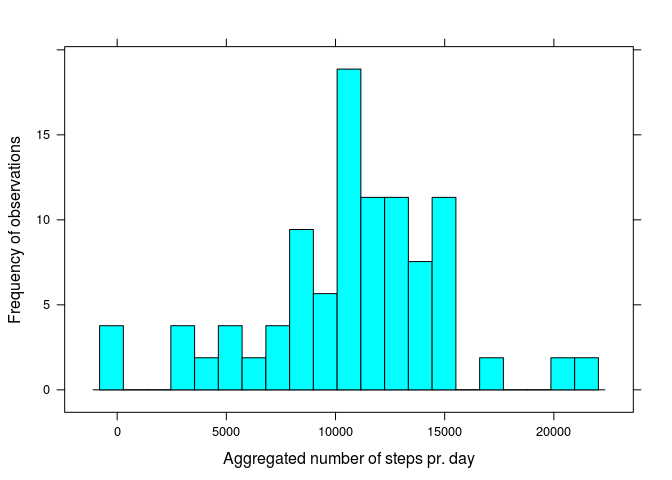

```r
#Finding the aggregated number of steps pr. day
ag.steps.pr.day <- aggregate(steps ~ date, dataset, sum)
#Plotting the histogram using the lattice package
library(lattice)
histogram(ag.steps.pr.day$steps, xlab = "Aggregated number of steps pr. day", ylab = "Frequency of observations", nint = 21)
```

### 2:

```r
#Finding the mean and median of aggregated steps per day
ds1mean <- mean(ag.steps.pr.day$steps)
ds1median <- median(ag.steps.pr.day$steps)
ds1mean
```

```
## [1] 10766.19
```

```r
ds1median
```

```
## [1] 10765
```

## What is the average daily activity pattern?

#### 1. Make a time series plot (i.e. type = “l”) of the 5-minute interval (x-axis)

#### and the average number of steps taken, averaged across all days (y-axis)

#### 2. Which 5-minute interval, on average across all the days in the dataset,

#### contains the maximum number of steps?

### 1:

```r
#Finding the mean aggregated number of steps per interval
mag.steps.pr.interval <- aggregate(steps ~ interval, dataset, mean)
```

### 1.1:

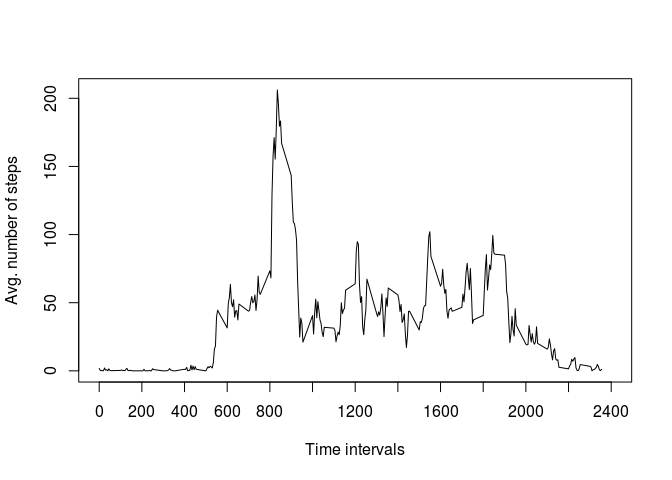

```r
#Plotting a time series graph of the result
plot(mag.steps.pr.interval$interval, mag.steps.pr.interval$steps, type = "l", ylab = "Avg. number of steps", xlab = "Time intervals", xlim = c(0, 2400), lab = c(12,4,0))
```

### 2:

```r
#Which interval contains the highest average number of steps
maxint <- mag.steps.pr.interval[which.max(mag.steps.pr.interval$steps),]
maxint[,1]
```

```
## [1] 835
```

## Imputing missing values

### 1:

```r
#How many row in the original dataset contains NA-values
sum(is.na(dataset$steps))
```

```
## [1] 2304
```

```r
#This could also have been found by the use of the summary() function
```

### 2:

#### The reason for missing values could be any…

#### Forgot to wear the gadget, no batteries, any other kind of issues

#### So in order to fill them in several approaches could be selected

#### Fill the missing with day-averages, or interval averages or any other kind of approaches

#### We could also use the mice package which includes several different ways to do this

#### I’ve decided to use the default “ppm” (predictive mean matching) with default iterations based on the assumption that the reason for the missing values a of technical reasons, and that the person has worn the gadget throughout the test-periode.

```r
#Loading the mice package
library(mice)
#Imputing the dataset
tempdata <- mice(dataset)
```

### 3:

```r
imputedData <- complete(tempdata, 1)
```

### 4:

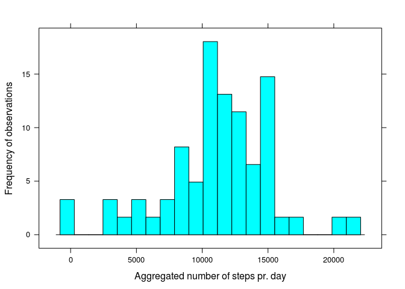

```r
#Finding the aggregated number of steps pr. day in the imputed dataset
ag.steps.pr.day.2 <- aggregate(steps ~ date, imputedData, sum)
#Histogram of the imputed dataset
histogram(ag.steps.pr.day.2$steps, xlab = "Aggregated number of steps pr. day", ylab = "Frequency of observations", nint = 21)
```

```r
#Finding the mean and median of aggregated steps per day on the imputed dataset
ds2mean <- mean(ag.steps.pr.day.2$steps)
ds2median <- median(ag.steps.pr.day.2$steps)
ds2mean
```

```
## [1] 11141.38
```

```r
ds2median
```

```
## [1] 11352
```

```r
meandiff <- ds2mean - ds1mean
mediandiff <- ds2median - ds1median
meandiff
```

```
## [1] 375.1884
```

```r
mediandiff
```

```
## [1] 587
```

## Are there differences in activity patterns between weekdays and weekends?

### For this part the weekdays() function may be of some help here. Use the dataset

### with the filled-in missing values for this part.

#### 1. Create a new factor variable in the dataset with two levels – “weekday”

#### and “weekend” indicating whether a given date is a weekday or weekend day.

#### 2. Make a panel plot containing a time series plot (i.e. type = “l”) of the

#### 5-minute interval (x-axis) and the average number of steps taken, averaged

#### across all weekday days or weekend days (y-axis).

### 1:

```r
#First we'll create a factor variable of daytypes
daytype <- weekdays(as.Date(imputedData$date))
#Now replace all workingdays to the string "weekday"
daytype <- replace(daytype, daytype %in% list("Monday", "Tuesday", "Wednesday", "Thursday", "Friday"), "weekday")
#The same for weekends
daytype <- replace(daytype, daytype %in% list("Saturday", "Sunday"), "weekend")
#And glue it together with the imputed dataset
imputedData <- cbind(imputedData, daytype)
#We now have a dataset to analyse
```

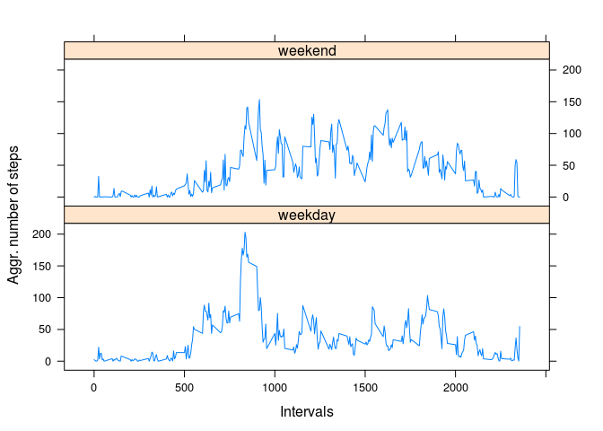

```r
#lets again find the mean of aggregated steps per interval
mag.steps.pr.interval.2 <- aggregate(steps ~ interval + daytype, imputedData, mean)
#Plotting a time series graph of the result
xyplot(mag.steps.pr.interval.2$steps ~ mag.steps.pr.interval.2$interval | daytype, data=mag.steps.pr.interval.2, type = "l", layout=c(1,2), xlab = "Intervals", ylab = "Aggr. number of steps")
```

#### We can clearly see a different pattern during weekends. Weekdays tend to have a peak around 0800 to 1000, whereas during weekends the number of steps seems to be more spread out all through the day.